# Coffee C Futures Price Model

Jacob Norman

2/19/2019

## Exploratory Data Analysis

```
## 'data.frame':    470 obs. of  7 variables:
##  $ date  : Date, format: "1980-01-01" "1980-02-01" ...
##  $ price : num  166 176 182 177 194 ...
##  $ open  : num  182 168 175 181 177 ...
##  $ high  : num  184 176 190 188 203 ...
##  $ low   : num  160 163 174 176 175 ...
##  $ volume: num  22520 8770 7300 10210 8790 ...
##  $ change: num  -0.0845 0.0558 0.0374 -0.031 0.0988 ...
```

Below is a table of the futures price data obtained from [*Investing.com*](https://www.investing.com/commodities/us-coffee-c-historical-data). The “price” column is synonomous with closing price, and is, therefore, the object of my analysis.

| date | price | open | high | low | volume | change |
| --- | --- | --- | --- | --- | --- | --- |
| 1980-01-01 | 166.39 | 182.10 | 183.75 | 160.10 | 22520 | -0.0845 |
| 1980-02-01 | 175.68 | 168.39 | 176.00 | 163.00 | 8770 | 0.0558 |
| 1980-03-01 | 182.25 | 174.75 | 190.00 | 174.50 | 7300 | 0.0374 |
| 1980-04-01 | 176.60 | 181.25 | 188.00 | 176.50 | 10210 | -0.0310 |
| 1980-05-01 | 194.05 | 177.10 | 203.00 | 174.75 | 8790 | 0.0988 |
| 1980-06-01 | 168.05 | 196.62 | 202.30 | 164.25 | 16990 | -0.1340 |
| 1980-07-01 | 143.06 | 172.00 | 174.00 | 130.50 | 20590 | -0.1487 |
| 1980-08-01 | 128.00 | 140.25 | 152.00 | 124.50 | 14090 | -0.1053 |
| 1980-09-01 | 126.66 | 124.62 | 138.25 | 119.00 | 9580 | -0.0105 |
| 1980-10-01 | 125.14 | 127.92 | 135.70 | 124.05 | 16510 | -0.0120 |
| 1980-11-01 | 114.75 | 124.37 | 124.60 | 102.10 | 9560 | -0.0830 |
| 1980-12-01 | 126.80 | 115.77 | 129.75 | 105.10 | 6200 | 0.1050 |
| 1981-01-01 | 122.36 | 126.70 | 134.80 | 118.10 | 18020 | -0.0350 |
| 1981-02-01 | 121.00 | 120.87 | 127.00 | 115.55 | 8220 | -0.0111 |
| 1981-03-01 | 128.66 | 121.00 | 131.40 | 116.50 | 8460 | 0.0633 |
| 1981-04-01 | 126.48 | 127.60 | 129.25 | 121.50 | 7260 | -0.0169 |
| 1981-05-01 | 113.78 | 126.40 | 127.90 | 110.10 | 5600 | -0.1004 |
| 1981-06-01 | 93.62 | 111.75 | 113.00 | 85.50 | 11400 | -0.1772 |
| 1981-07-01 | 123.13 | 95.50 | 134.40 | 90.90 | 12810 | 0.3152 |
| 1981-08-01 | 99.90 | 122.56 | 127.45 | 99.50 | 15710 | -0.1887 |
| 1981-09-01 | 129.15 | 98.87 | 132.50 | 98.10 | 9770 | 0.2928 |
| 1981-10-01 | 141.12 | 131.25 | 144.40 | 129.25 | 23160 | 0.0927 |
| 1981-11-01 | 136.61 | 141.37 | 155.25 | 135.65 | 11940 | -0.0320 |
| 1981-12-01 | 139.71 | 137.25 | 159.00 | 134.00 | 5430 | 0.0227 |
| 1982-01-01 | 149.14 | 140.85 | 150.50 | 135.10 | 29120 | 0.0675 |
| 1982-02-01 | 153.98 | 150.02 | 162.30 | 147.50 | 17300 | 0.0325 |
| 1982-03-01 | 128.56 | 152.98 | 162.90 | 124.50 | 14460 | -0.1651 |
| 1982-04-01 | 141.72 | 129.88 | 143.75 | 129.20 | 19070 | 0.1024 |
| 1982-05-01 | 138.23 | 141.18 | 144.95 | 119.50 | 16540 | -0.0246 |
| 1982-06-01 | 140.60 | 134.25 | 142.25 | 133.30 | 16890 | 0.0171 |

[output cut: 440 more lines]

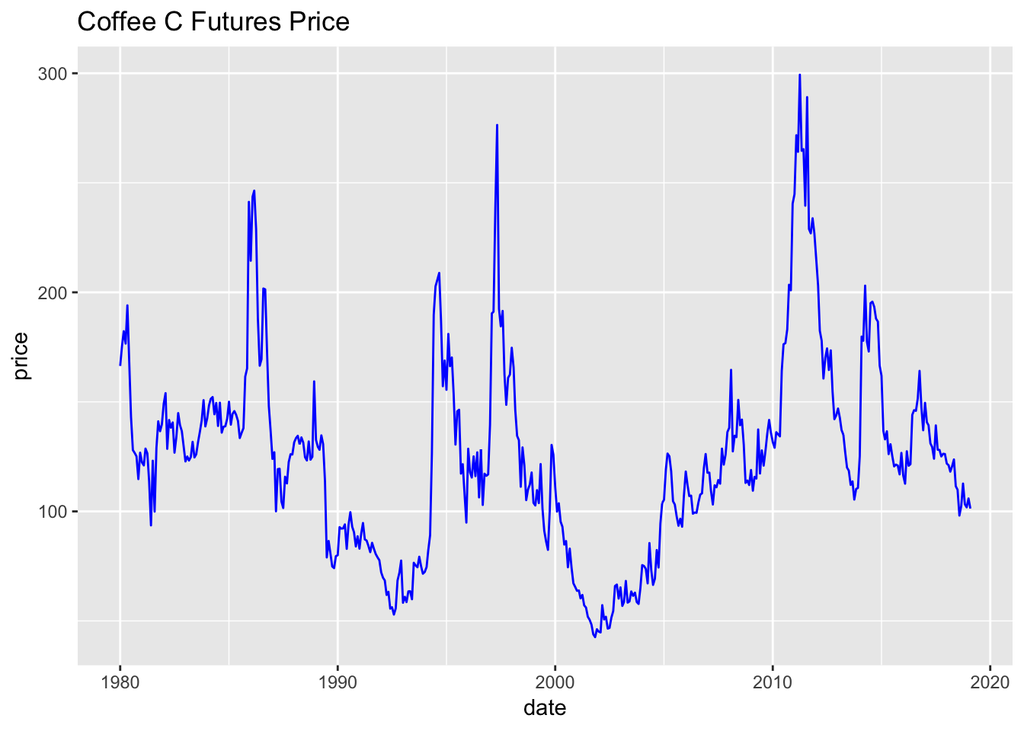

Here is a quick summary of the futures price data, from 1980 to present. It looks strikingly similar to the spot price during the same period. We know from the optimal hedge ratio analysis that the spot and futures price of arabica coffee beans have a correlation coefficient of 0.9666.

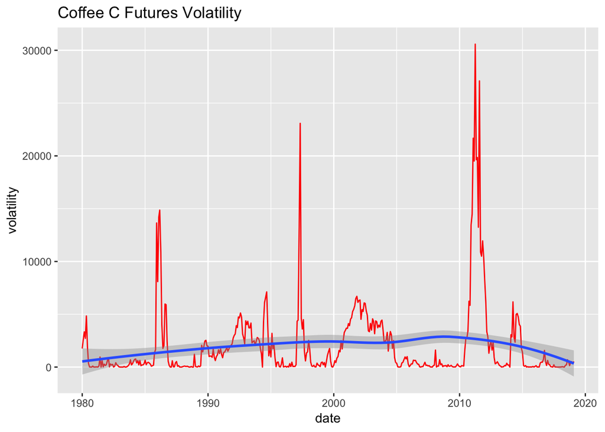

A time series look at the volatility shows that it definitely changes over time, with significant highly-volatile periods. This is my first indication that a *general autoregressive conditional heteroskedasticity* (GARCH) model my be a great way to model the data.

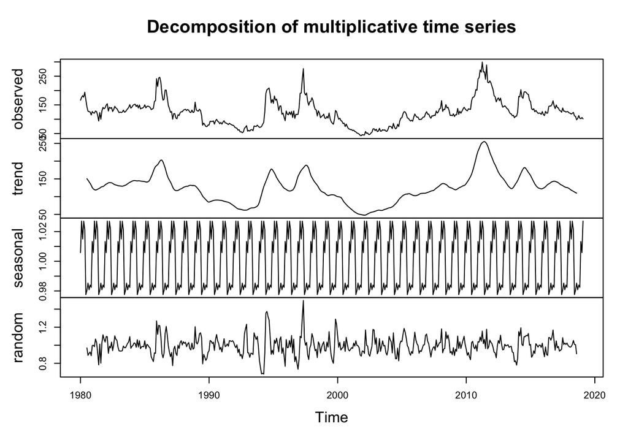

This is a decomposition of the various parts of the time series. We see there is a clear and definite seasonality to the data. The trend is less obvious, seemingly rising and falling at various points.

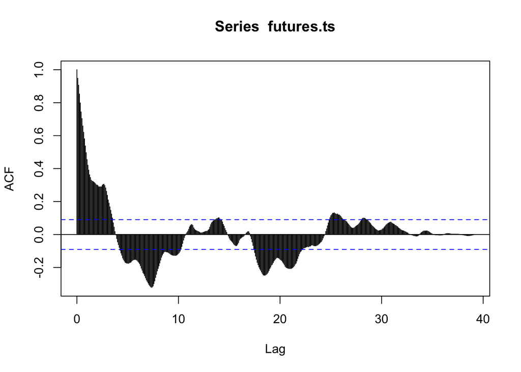

```r
plot(acf(futures.ts, lag.max = 500, plot = FALSE))
```

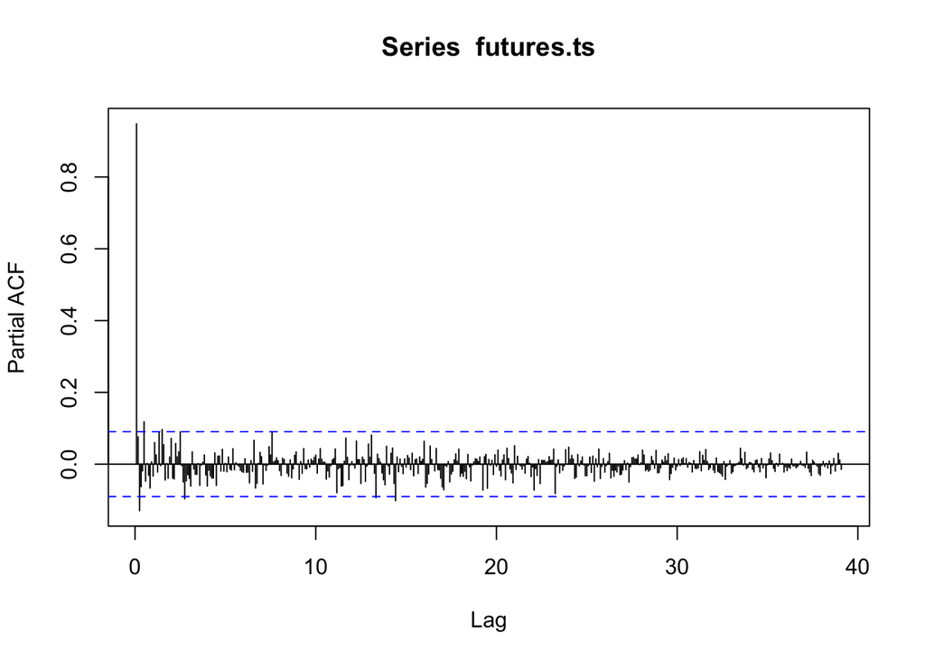

```r
pacf(futures.ts, lag.max = 500)
```

Here are the *autocorrelation function* (ACF) and *partal autocorrelation function* (PACF). There is clearly something interesting going in the ACF. This suggests there is some sort of autocorrelation of the time series data. The PACF only has one significant lag and then there is a steep drop.

## Seasonal ARIMA Model

Since this data is definitely seasonal, let’s fit a *seasonal autoregressive integrated moving average* (SARIMA) model to the data.

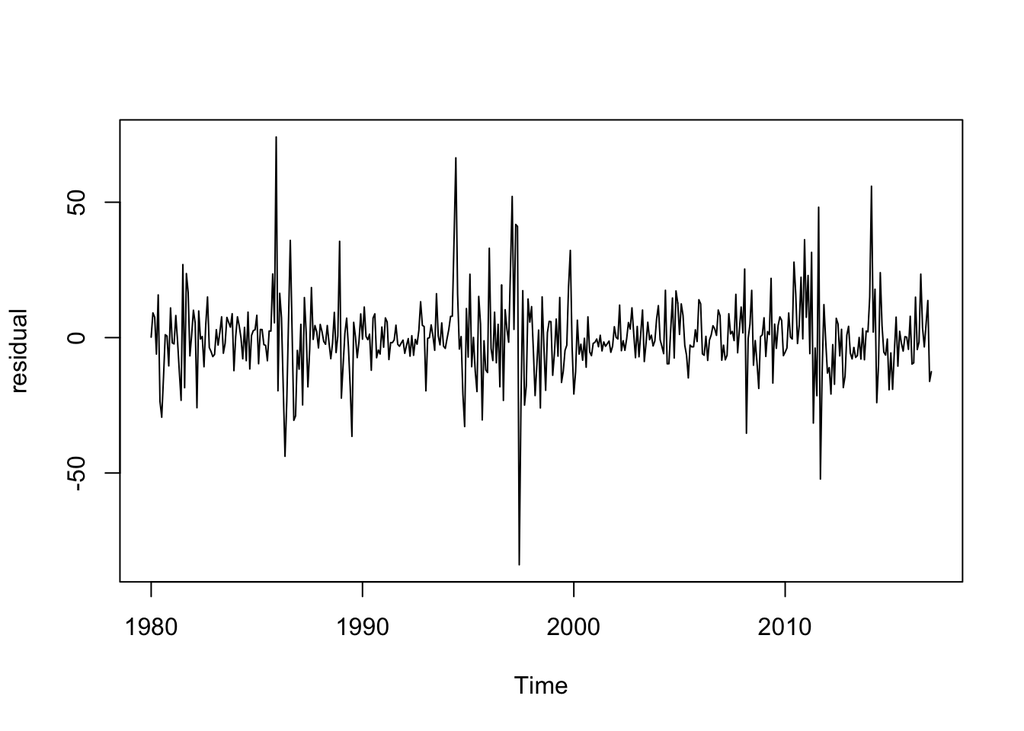

R has a function called `auto.arima()` which fits an arima model to a time series and selects the parameters based on the lowest possible AIC, a measure of error. For the futures data, the function fit an **ARIMA(0,1,2)(2,0,0)[12]** model to the data. I only fit this model on data before 2017, so I can test the predictions on data after 2017, which I have the actuals of.

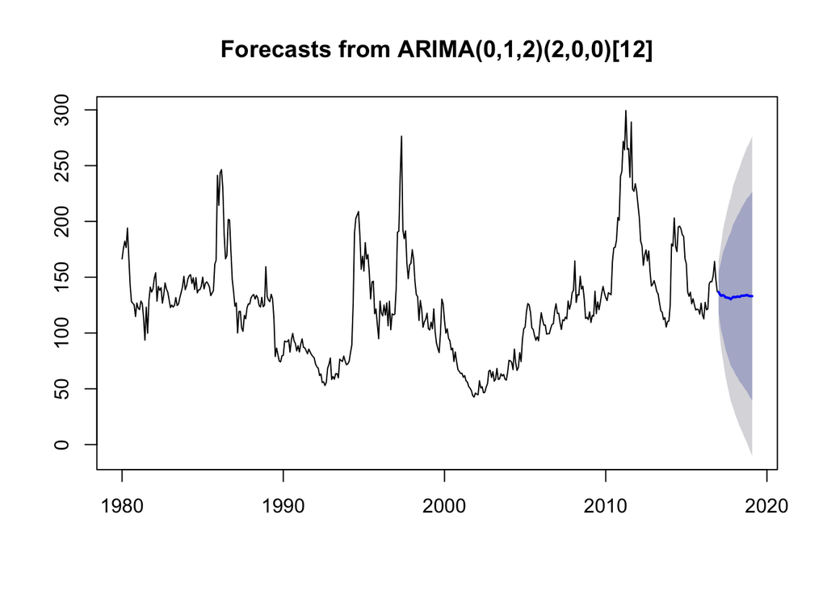

Just looking at the predictions (the blue line), it is very flat. This data never has any periods of consistently stable prices. I do not like this, but let’s check how it the residual analysis turns out.

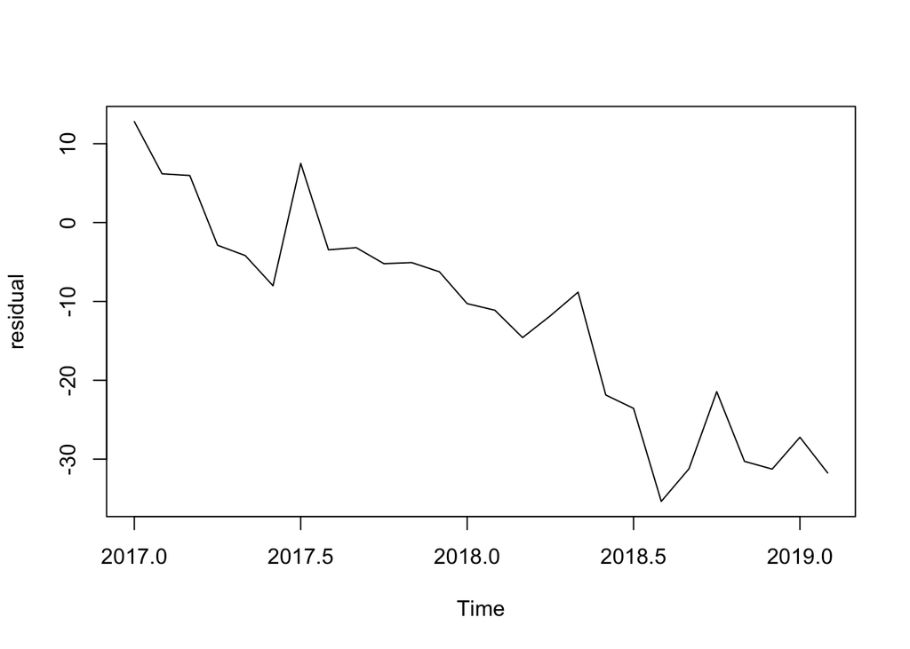

```r
plot.ts(test.ts - test.forecast$mean, ylab = "residual")
```

```r
cat(sprintf("Mean residual deviations:\t%.4f", mean(test.ts - test.forecast$mean)))
```

```
## Mean residual deviations:    -12.1677
```

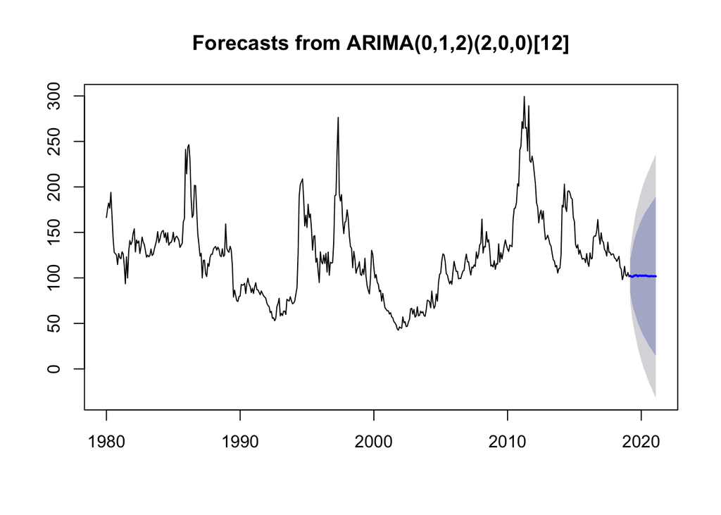

It looks very flat. I do not like this model. It’s predictive ability is extremely limited at best. In my earlier analysis, the `auto.arima()` function fit an **ARIMA(2,1,2)** model to the complete time series of the spot price. Since they have a correlation of 0.9666, it seems reasonable to use the same ARIMA model for the futures price.

## GARCH Model

Let’s combine the **ARIMA(2,1,2)** model with a **GARCH(1,1)** model. We have already noted that the data does not observe a constant variance, and a GARCH(1,1) model is great for modeling financial data.

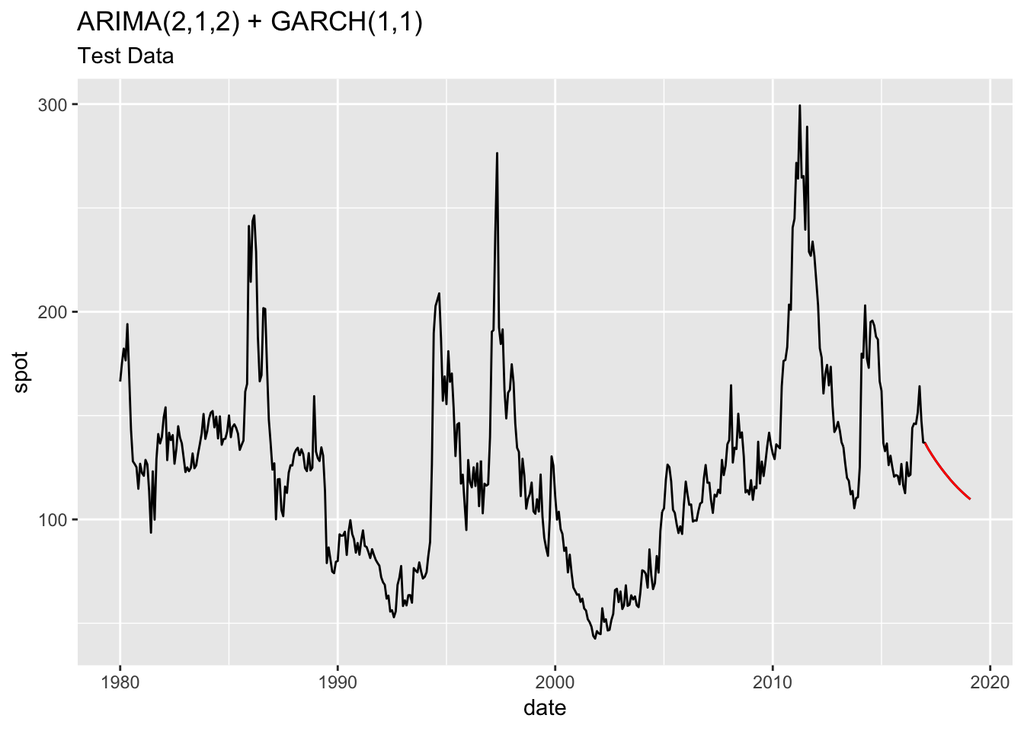

This looks much better; the red is the predicted futures price. Looking at the true data, we know that the futures prices continues to fall through February 2019, so this is a more accurate prediction. Let’s look at the residuals just to be safe.

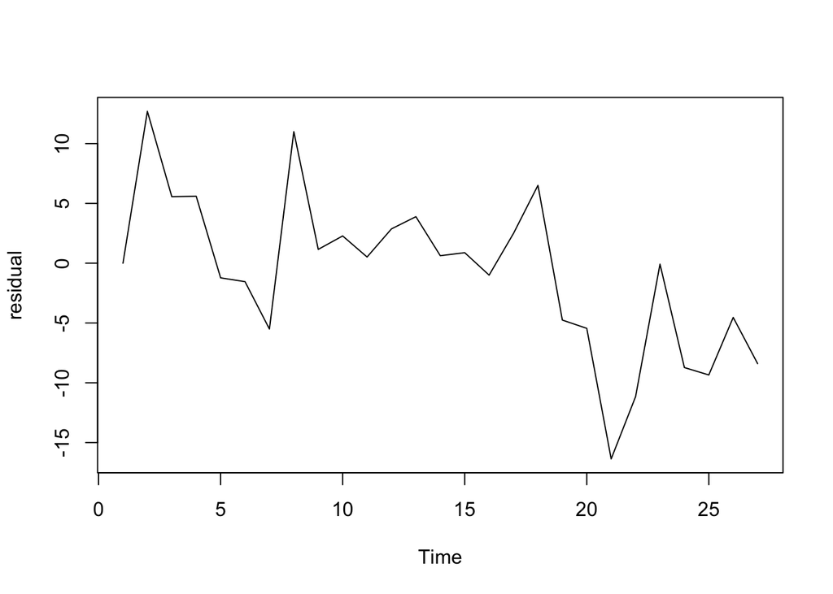

```
## Mean residual deviation: -0.8151
```

The residuals have a mean much closer to 0. This is the desired behavior. Let’s fit the full model now.

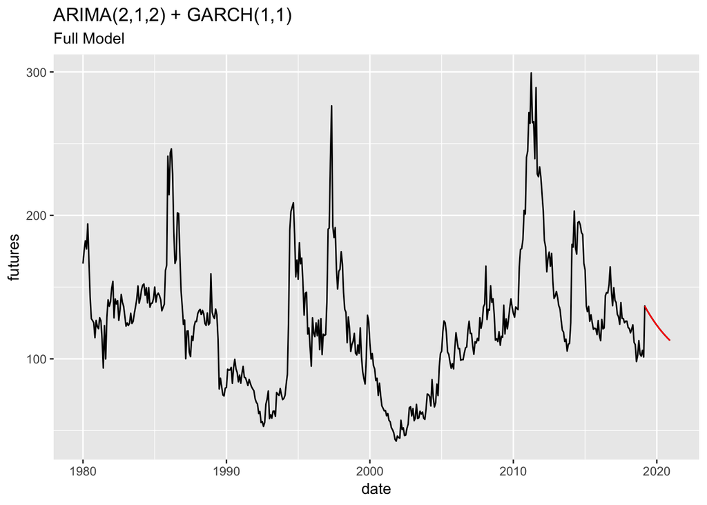

It appears that the model predicts the futures price will continue its downwards trajectory through 2020.

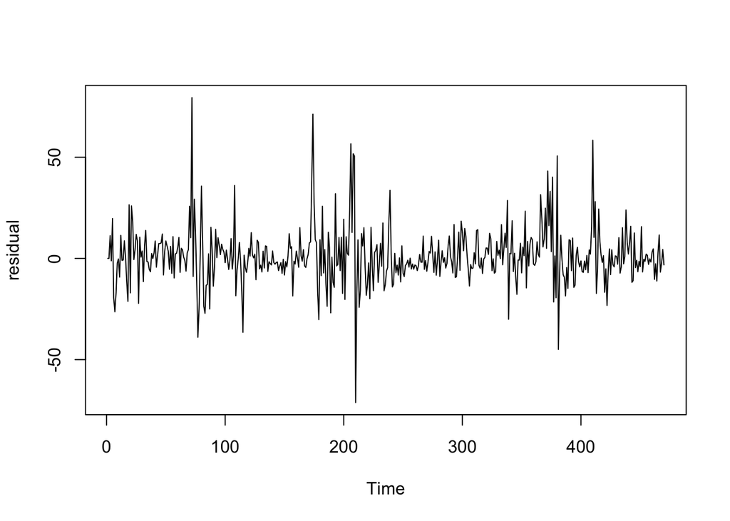

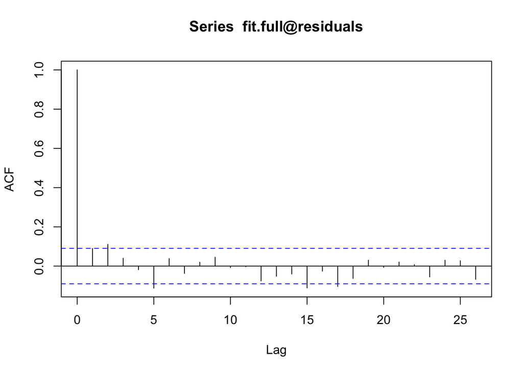

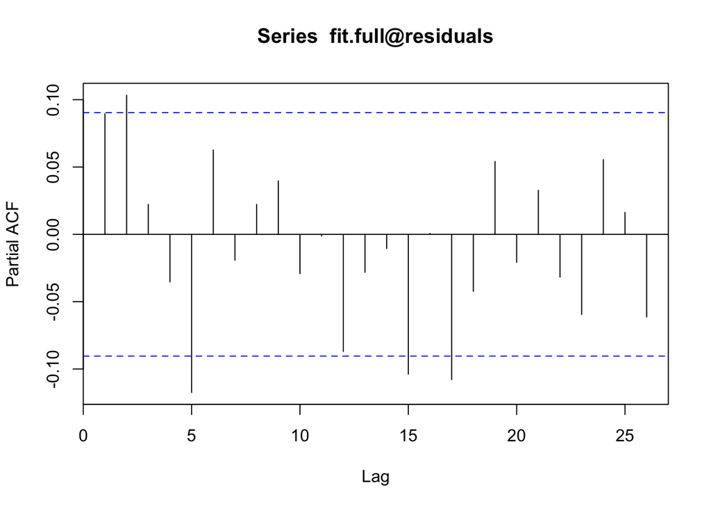

|  | date | price |
| --- | --- | --- |
| 471 | 2019-03-01 | 136.8495 |
| 472 | 2019-04-01 | 135.1329 |
| 473 | 2019-05-01 | 133.6999 |
| 474 | 2019-06-01 | 132.2735 |
| 475 | 2019-07-01 | 130.8945 |
| 476 | 2019-08-01 | 129.5554 |
| 477 | 2019-09-01 | 128.2558 |
| 478 | 2019-10-01 | 126.9946 |
| 479 | 2019-11-01 | 125.7704 |
| 480 | 2019-12-01 | 124.5824 |
| 481 | 2020-01-01 | 123.4294 |
| 482 | 2020-02-01 | 122.3103 |
| 483 | 2020-03-01 | 121.2242 |
| 484 | 2020-04-01 | 120.1702 |
| 485 | 2020-05-01 | 119.1471 |
| 486 | 2020-06-01 | 118.1543 |
| 487 | 2020-07-01 | 117.1906 |
| 488 | 2020-08-01 | 116.2554 |
| 489 | 2020-09-01 | 115.3478 |
| 490 | 2020-10-01 | 114.4668 |
| 491 | 2020-11-01 | 113.6119 |
| 492 | 2020-12-01 | 112.7821 |